# Loan Characteristics affecting Borrower's APR from Prosper Loan Data

## Investigation Overview

> In this investigation, I wanted to look at the characteristics of loans that could be used to predict their borrower APR. After exploring different characteristics, I restricted my focus on the following loan characteristics:-
> - Original loan amount
> - Borrower's Prosper rating
> - Loan term
> - Borrower's stated monthly income.

## Dataset Overview

```python
# import all packages and set plots to be embedded inline
import numpy as np
import pandas as pd
import matplotlib.pyplot as plt
import seaborn as sb

%matplotlib inline

# suppress warnings from final output
import warnings
warnings.simplefilter("ignore")
```

```python
# load in the dataset into a pandas dataframe
# load in the dataset into a pandas dataframe
df = pd.read_csv('../prosperLoanData.csv')
# Subset the dataframe by selecting features of interest
cols = ['LoanOriginalAmount', 'BorrowerAPR', 'StatedMonthlyIncome', 'Term', 'ProsperRating (Alpha)',
        'EmploymentStatus']
df_sub = df[cols]

# data wrangling, impute APR for missing Borrower APR records
borrower_fees = df["BorrowerAPR"] - df["BorrowerRate"]
borrower_fees.median()
df_sub["BorrowerAPR"].fillna(df["BorrowerRate"] + borrower_fees.median(), inplace=True)


# data wrangling, remove loans with stated monthly income greater than 30k, which are outliers
df_sub = df_sub[df_sub.StatedMonthlyIncome<=30000]
# Convert Term, ProsperRating and Employment status into ordered categorical types
term_order = [12, 36, 60]
ordered_var = pd.api.types.CategoricalDtype(ordered = True, categories = term_order)
df_sub['Term'] = df_sub['Term'].astype(ordered_var)

rate_order = ['HR','E','D','C','B','A','AA']
ordered_var = pd.api.types.CategoricalDtype(ordered = True,
                                    categories = rate_order)
df_sub['ProsperRating (Alpha)'] = df_sub['ProsperRating (Alpha)'].astype(ordered_var)

emp_order = ['Employed','Self-employed','Full-time','Part-time','Retired','Other','Not employed', 'Not available']
ordered_var = pd.api.types.CategoricalDtype(ordered = True,
                                    categories = emp_order)
df_sub['EmploymentStatus'] = df_sub['EmploymentStatus'].astype(ordered_var)
print(df_sub.info())
print(df_sub.shape)
```

```
<class 'pandas.core.frame.DataFrame'>
Int64Index: 113610 entries, 0 to 113936
Data columns (total 6 columns):
LoanOriginalAmount       113610 non-null int64
BorrowerAPR              113610 non-null float64
StatedMonthlyIncome      113610 non-null float64
Term                     113610 non-null category
ProsperRating (Alpha)    84604 non-null category
EmploymentStatus         111364 non-null category
dtypes: category(3), float64(2), int64(1)
memory usage: 3.8 MB
None
(113610, 6)
```

```python
df_sub.head()
```

|  | LoanOriginalAmount | BorrowerAPR | StatedMonthlyIncome | Term | ProsperRating (Alpha) | EmploymentStatus |
| --- | --- | --- | --- | --- | --- | --- |
| 0 | 9425 | 0.16516 | 3083.333333 | 36 | NaN | Self-employed |
| 1 | 10000 | 0.12016 | 6125.000000 | 36 | A | Employed |
| 2 | 3001 | 0.28269 | 2083.333333 | 36 | NaN | Not available |
| 3 | 10000 | 0.12528 | 2875.000000 | 36 | A | Employed |
| 4 | 15000 | 0.24614 | 9583.333333 | 36 | D | Employed |

## Distribution of Borrower APR

The distribution of Borrower APR looks slightly multimodal. A small peak centered at 0.1, a large peak centered at 0.2. There is also a small peak centered 0.3. Additionally, there is a very sharpe peak between 0.35 and 0.36.Very few loans have Borrower APR greater than 0.43

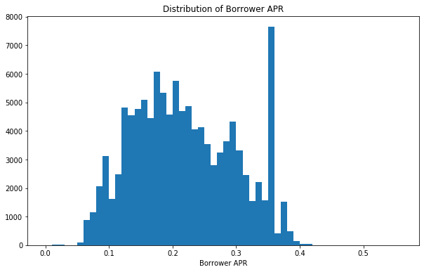

```python
bins = np.arange(0, df_sub.BorrowerAPR.max()+0.05, 0.01)
plt.figure(figsize=[10, 6])
plt.hist(data = df_sub, x = 'BorrowerAPR', bins = bins);
plt.xlabel('Borrower APR')
plt.title('Distribution of Borrower APR');
```

## Distribution of Original Loan Amount

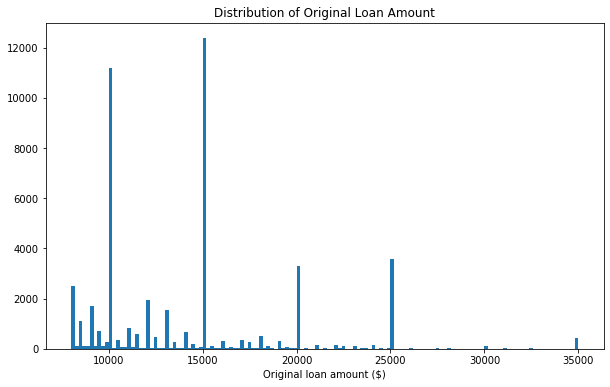

```python
bins = np.arange(8000, df_sub.LoanOriginalAmount.max()+200, 200)
plt.figure(figsize=[10, 6])
plt.hist(data = df_sub, x = 'LoanOriginalAmount', bins = bins);
plt.xlabel('Original loan amount ($)');
plt.title('Distribution of Original Loan Amount');
```

## Borrower APR vs. Loan Amount

At different size of the loan amount, the APR has a large range, but the range of APR decrease with the increase of loan amount. Overall, the borrower APR decrease with increase of loan amount

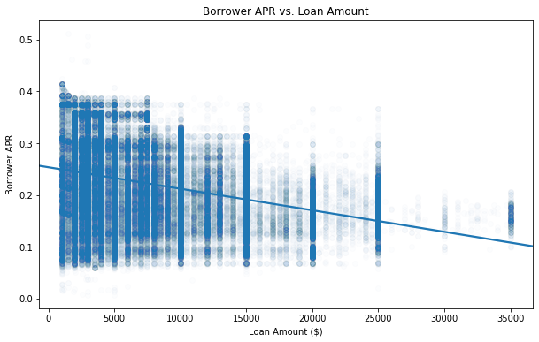

```python
plt.figure(figsize = [10, 6])
sb.regplot(data = df_sub, x = 'LoanOriginalAmount', y = 'BorrowerAPR', scatter_kws={'alpha':0.01});
plt.xlabel('Loan Amount ($)')
plt.ylabel('Borrower APR')
plt.title('Borrower APR vs. Loan Amount');
```

## Borrower APR vs. Prosper Rating

The borrower APR decreases with better Prosper rating. Borrowers with the best Prosper ratings have the lowest APR. It means that the Prosper rating has a strong effect on Borrower APR.

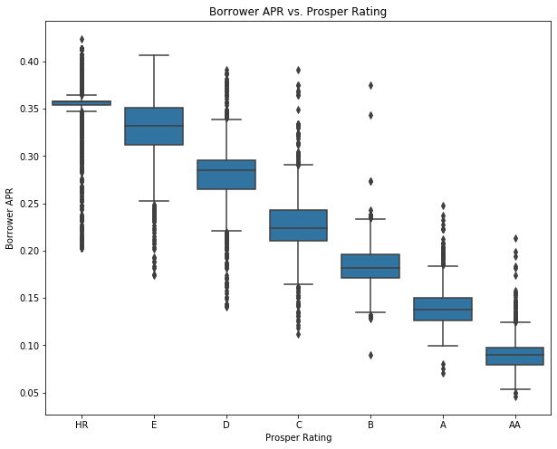

```python
plt.figure(figsize=[10,8])
default_color = sb.color_palette()[0]
sb.boxplot(data=df_sub, x='ProsperRating (Alpha)', y='BorrowerAPR', color=default_color)
plt.xlabel('Prosper Rating')
plt.ylabel('Borrower APR')
plt.title('Borrower APR vs. Prosper Rating');
```

## Prosper Rating Effect on Relationship between APR and Loan Amount

The borrower APR decreases with better rating whereas the loan amount increases with better rating. Interestingly, the relationship between Borrower APR and Loan amount turns from negative to slightly positive when the Prosper ratings are increased from HR to A or better. This may be because people with A or AA ratings tend to borrow more money and increasing APR could prevent them from borrowing even more and maximize the profit. But people with lower ratings tend to borrow less money, hence decreasing APR for higher loan amounts for them could encourage them to borrow more.

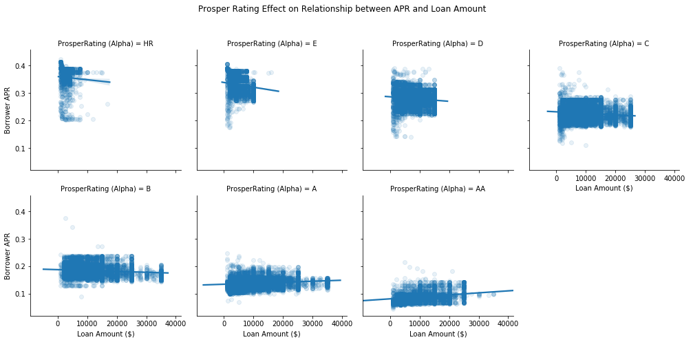

```python
# g=sb.FacetGrid(data=df_sub,col='ProsperRating (Alpha)', height=3.5, col_wrap=4)
# g.map(sb.regplot, 'LoanOriginalAmount', 'BorrowerAPR', x_jitter=0.04, scatter_kws={'alpha':0.1});
# g.set_titles('{col_name}')
# g.add_legend();
# g.set_xlabels('Loan Amount ($)')
# g.set_ylabels('Borrower APR')
# plt.suptitle('Prosper Rating Effect on Relationship between APR and Loan Amount');
# plt.subplots_adjust(top=0.85)

# Prosper rating effect on relationship of APR and loan amount
# plt.figure(figsize=[15,10]);
g=sb.FacetGrid(data=df_sub, height=3.5, col='ProsperRating (Alpha)', col_wrap=4);
g.map(sb.regplot, 'LoanOriginalAmount', 'BorrowerAPR', x_jitter=0.04, scatter_kws={'alpha':0.1});
g.add_legend();
g.set_xlabels('Loan Amount ($)')
g.set_ylabels('Borrower APR')
plt.suptitle('Prosper Rating Effect on Relationship between APR and Loan Amount');
plt.subplots_adjust(top=0.85);
```

## Borrower APR by Rating and Term

Interestingly, the borrower APR decreases with the increase of borrow term for people with HR-C ratings. But for people with B-AA ratings, the APR increase with the increase of borrow term.

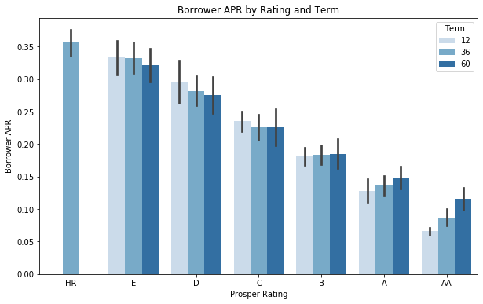

```python
fig = plt.figure(figsize = [10,6])
sb.barplot(data = df_sub, x = 'ProsperRating (Alpha)', y = 'BorrowerAPR', hue = 'Term',
            palette = 'Blues', dodge = 0.4, ci='sd');
plt.ylabel('Borrower APR')
plt.xlabel('Prosper Rating')
plt.title('Borrower APR by Rating and Term');
```